# Informe Hito 3

## 1- Motivacion:

La motivación de este proyecto consiste en analizar los factores que influyen en el éxito de las citas rápidas, específicamente en la atracción mutua entre los participantes. Con este fin, se utiliza un dataset que contiene información sobre más de 8000 citas realizadas entre 2002 y 2004 en Estados Unidos. Este dataset comprende variables demográficas, de personalidad, de intereses y de preferencias de los participantes, además del resultado de cada cita (si se produjo o no un 'match'). El objetivo principal es identificar patrones y tendencias que determinen la compatibilidad entre las personas, y brindar una visión de los atributos más relevantes a la hora de encontrar pareja.

### Limpieza de datos

Antes de comenzar con la exploración, se realizará una limpieza general de los datos para facilitar el trabajo con ellos. A continuación, se detallan los cambios que se llevarán a cabo:

1. Reemplazar todos los datos del tipo "b0" (same race, decision, decision_o y match) por el entero correspondiente.
2. Reemplazar los atributos del tipo "b atributo" por "atributo".
3. Asignar nombres más intuitivos a las etnias de los participantes.

## 2- Exploracion de datos:

En el siguiente apartado se mostraran los datos de las columnas de manera general, para luego realizar un analisis mas detallado de las más importantes.

| index | wave | age | age_o | d_age | importance_same_race | importance_same_religion | pref_o_attractive | pref_o_sincere | pref_o_intelligence | pref_o_funny | pref_o_ambitious | pref_o_shared_interests | attractive_o | sinsere_o | intelligence_o | funny_o | ambitous_o | shared_interests_o | attractive_important | sincere_important |
| --- | --- | --- | --- | --- | --- | --- | --- | --- | --- | --- | --- | --- | --- | --- | --- | --- | --- | --- | --- | --- |
| count | 8378.0 | 8283.0 | 8274.0 | 8378.0 | 8299.0 | 8299.0 | 8289.0 | 8289.0 | 8289.0 | 8280.0 | 8271.0 | 8249.0 | 8166.0 | 8091.0 | 8072.0 | 8018.0 | 7656.0 | 7302.0 | 8299.0 | 8299.0 |
| mean | 11.350919073764622 | 26.358927924664975 | 26.36499879139473 | 4.1856051563619 | 3.7847933485962164 | 3.651644776479094 | 22.495346845216552 | 17.39686693207866 | 20.27075883701291 | 17.45971376811594 | 10.68537540805223 | 11.845930415807977 | 6.190411462160177 | 7.175256457792609 | 7.369301288404361 | 6.400598653030681 | 6.778409090909091 | 5.474869898657902 | 22.51463188335944 | 17.396388721532716 |
| std | 5.995903041209956 | 3.5667625561014322 | 3.5636483364286153 | 4.596171468392849 | 2.845707759718648 | 2.8052370077509434 | 12.569801839920249 | 7.044002879087768 | 6.782895408058749 | 6.085525745939867 | 6.126543670040548 | 6.362745543712426 | 1.9503054298615266 | 1.7405754111173022 | 1.5505009306117339 | 1.954077914836438 | 1.7940798581056134 | 2.1561631824645504 | 12.58767385525755 | 7.046700285982147 |
| min | 1.0 | 18.0 | 18.0 | 0.0 | 0.0 | 1.0 | 0.0 | 0.0 | 0.0 | 0.0 | 0.0 | 0.0 | 0.0 | 0.0 | 0.0 | 0.0 | 0.0 | 0.0 | 0.0 | 0.0 |
| 25% | 7.0 | 24.0 | 24.0 | 1.0 | 1.0 | 1.0 | 15.0 | 15.0 | 17.39 | 15.0 | 5.0 | 9.52 | 5.0 | 6.0 | 6.0 | 5.0 | 6.0 | 4.0 | 15.0 | 15.0 |
| 50% | 11.0 | 26.0 | 26.0 | 3.0 | 3.0 | 3.0 | 20.0 | 18.37 | 20.0 | 18.0 | 10.0 | 10.64 | 6.0 | 7.0 | 7.0 | 7.0 | 7.0 | 6.0 | 20.0 | 18.18 |
| 75% | 15.0 | 28.0 | 28.0 | 5.0 | 6.0 | 6.0 | 25.0 | 20.0 | 23.81 | 20.0 | 15.0 | 16.0 | 8.0 | 8.0 | 8.0 | 8.0 | 8.0 | 7.0 | 25.0 | 20.0 |
| max | 21.0 | 55.0 | 55.0 | 37.0 | 10.0 | 10.0 | 100.0 | 60.0 | 50.0 | 50.0 | 53.0 | 30.0 | 10.5 | 10.0 | 10.0 | 11.0 | 10.0 | 10.0 | 100.0 | 60.0 |

## Variables a Explorar:

Una vez hecha la limpieza del dataset, se procedera a indagar sobre los comportamientos de los distintos atributos.

Los atributos que consideramos los más importantes son:

- Edades
- Cualidades(Inteligencia,Atractivo,etc)
- Raza
- Relacion Puntuación Match

## Edad y matches:

Se busca determinar si la edad tiene alguna influencia en la cantidad de matches que una persona obtiene. Para ello, se presenta un gráfico que muestra la distribución de la cantidad de matches en función de la edad. Se observa que la edad de 25 años presenta la mayor cantidad de matches, y en los primeros años se aprecia una distribución bastante normal. Sin embargo, a partir de los 30 años se observa una disminución curiosa, seguida de una ligera recuperación con otra distribución normal y, finalmente, se presentan algunos valores atípicos.

Una posible explicación para la disminución a los 30 años es que esta edad marca una transición significativa de joven adulto a adulto. Por lo tanto, se podría asumir que las preferencias de las personas antes de esta edad difieren de las que tienen después.

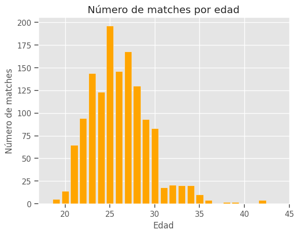

### Exporacion de Cualidades:

Una vez completada la exploración general de las edades de los participantes, resulta interesante analizar los hallazgos en relación a las cualidades evaluadas por estos. Para ello, se visualizan los atributos de "atractivo", "sinceridad", "inteligencia", "gracioso/a" y "ambición" proporcionados por el dataset en tres instancias diferentes:

1. Puntuación propia del individuo en relación a estos atributos (en una escala del 1 al 10).
2. Puntuación de la pareja sobre el individuo en relación a estos atributos (en una escala del 1 al 10).
3. Preferencias de los individuos en cuanto a estos atributos (dividiendo el 100% entre los atributos).

Una pregunta interesante a explorar es cómo varía la percepción propia de los sujetos en relación a estos atributos en comparación con la percepción de sus parejas. Para visualizar esto, se han agrupado los datos según la evaluación propia del individuo y la evaluación de su pareja.

Posteriormente, se calculan los promedios de estas evaluaciones para cada atributo. Los resultados son los siguientes:

Se observa que, en promedio, los sujetos tienden a sobrevalorar sus atributos en comparación con la opinión de sus parejas. Es destacable mencionar que la mayor discrepancia de estimación se produce en el atributo "gracioso/a".

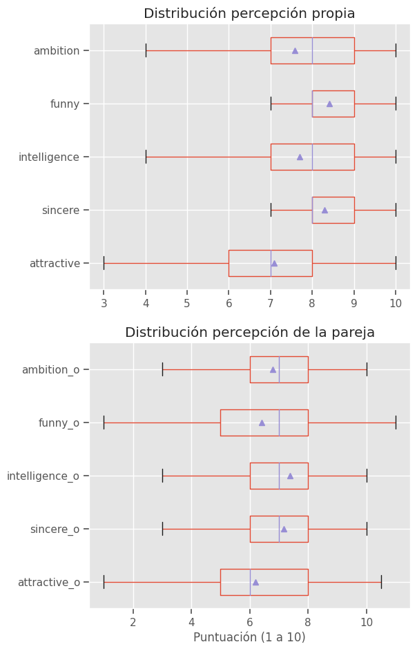

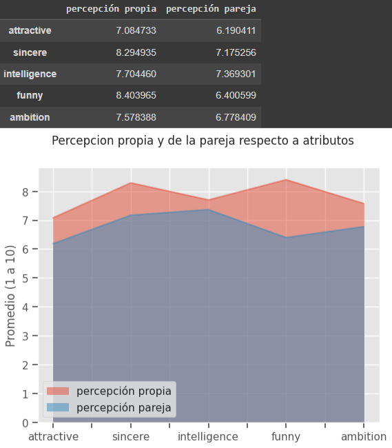

Es posible deducir que, en promedio, los sujetos tienden a sobrestimar sus atributos en comparación con la opinión de sus parejas. Es interesante mencionar que la mayor discrepancia en la estimación se produce en el atributo "gracioso/a".

## Por genero:

Esta tabla muestra la distribución de la importancia de diferentes atributos para cada género. Se observa que el atributo más importante difiere según el género. En el caso de los hombres, el atributo más importante es "atractivo/a", mientras que en el caso de las mujeres es "inteligencia".

### Las preferencias de las mujeres son:

| index | attractive_important | sincere_important | intellicence_important | funny_important | ambtition_important |
| --- | --- | --- | --- | --- | --- |
| count | 4125.0 | 4125.0 | 4125.0 | 4125.0 | 4125.0 |
| mean | 18.05522424242424 | 18.305008484848486 | 21.00250181818182 | 17.14729212121212 | 12.827221818181819 |
| std | 9.496918877522354 | 6.755333574185777 | 6.778147423018744 | 5.532109709704085 | 5.481803285013603 |
| min | 0.0 | 0.0 | 2.0 | 0.0 | 0.0 |
| 25% | 13.04 | 15.0 | 18.0 | 15.0 | 10.0 |
| 50% | 15.38 | 20.0 | 20.0 | 17.78 | 15.0 |
| 75% | 20.0 | 20.0 | 25.0 | 20.0 | 16.67 |
| max | 90.0 | 60.0 | 50.0 | 40.0 | 30.0 |

### Las preferencias de los hombres son:

| index | attractive_important | sincere_important | intellicence_important | funny_important | ambtition_important |
| --- | --- | --- | --- | --- | --- |
| count | 4174.0 | 4174.0 | 4174.0 | 4164.0 | 4154.0 |
| mean | 26.92168902731193 | 16.49843555342597 | 19.53737422137039 | 17.76389289145053 | 8.55282859894078 |
| std | 13.66966315854368 | 7.21245522332511 | 6.709546014553841 | 6.573848143437641 | 5.985803195076731 |
| min | 6.67 | 0.0 | 0.0 | 0.0 | 0.0 |
| 25% | 20.0 | 10.0 | 16.67 | 15.0 | 5.0 |
| 50% | 23.905 | 17.39 | 20.0 | 18.75 | 10.0 |
| 75% | 30.0 | 20.0 | 23.08 | 20.0 | 12.0 |
| max | 100.0 | 40.0 | 42.86 | 50.0 | 53.0 |

## Raza:

Es interesante destacar este atributo, ya que puede revelar posibles preferencias raciales y sesgos dentro del conjunto de participantes. Para abordar este análisis, se han agrupado los participantes por raza y se han contabilizado la cantidad de likes (decisiones positivas) y matches obtenidos (Gráfico 1). En este caso, se están considerando las cantidades totales. Posteriormente, se calcularán estos mismos atributos (matches y likes), pero tomando en cuenta su promedio.

Es importante tener en cuenta que al realizar el análisis de likes y matches en la base de datos, es posible llegar a conclusiones erróneas sobre su distribución real. Si nos enfocamos únicamente en el primer gráfico, podríamos concluir que la cantidad de matches y likes es significativamente mayor para personas de origen europeo, y que estas tienen más probabilidades de recibir un like o un match. Sin embargo, no estaríamos considerando la proporción de personas de cada raza, lo cual nos proporcionaría una perspectiva más completa. Por ejemplo, puede haber más de 4000 participantes de origen europeo y menos de 500 de origen latino.

Por lo tanto, se ha creado un gráfico que toma en cuenta tanto la cantidad de likes y matches como la cantidad de participantes por cada raza, lo que nos brinda un porcentaje de likes y matches en relación a la población de cada raza. Esto nos permite observar las diferencias entre ellas. Es importante destacar que recibir un like no necesariamente implica obtener un match.

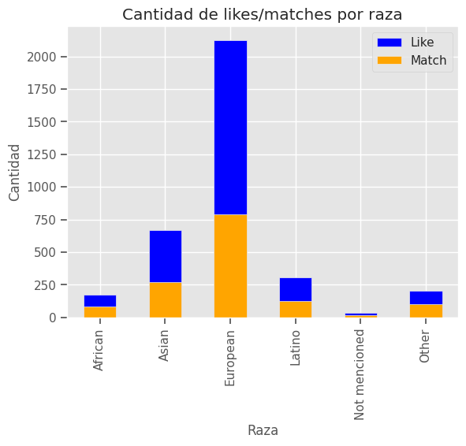

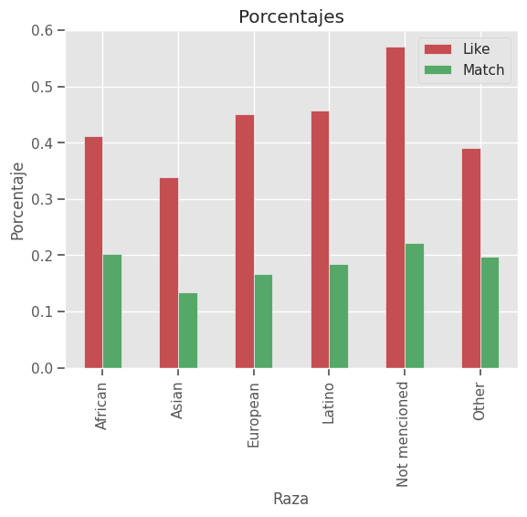

## Puntuacion - match:

A partir del análisis del gráfico, se observa una correlación predecible entre la puntuación y las decisiones positivas recibidas por los sujetos. A medida que aumenta la puntuación, se incrementa la cantidad de decisiones positivas otorgadas hacia ellos. Este gráfico nos proporciona una escala de probabilidad en relación a las decisiones positivas sobre un sujeto. Por ejemplo, si se recibe una puntuación de 4, existe aproximadamente un 10% de probabilidad de gustarle a la otra persona.

Este hallazgo sugiere que la percepción general y la evaluación de la pareja influyen en las decisiones positivas y, por ende, en la probabilidad de establecer un match.

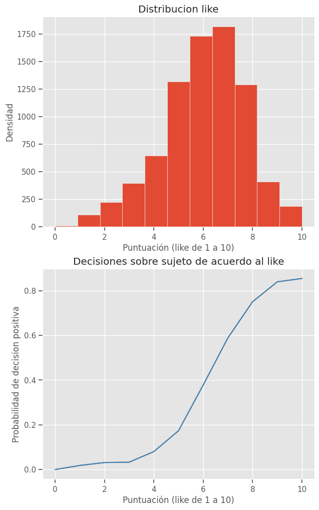

## Preguntas y problemas:

En base a la exploración anterior, nos planteamos abordar las siguientes preguntas en los hitos posteriores:

1. ¿Qué es lo más importante durante una cita? ¿La raza de una persona tiene relevancia en la obtención de likes o matches?
   - Se pretende entrenar un modelo de clasificación interpretativo, como un árbol de decisión, para identificar los atributos más relevantes a la hora de generar un match.
2. ¿Es posible predecir si una cita resultará en un match en función de los atributos de los sujetos?
   - Se buscará desarrollar un modelo predictivo enfocado en obtener una métrica de clasificación precisa para los matches.
3. ¿Existen estereotipos reconocibles entre los participantes de las citas rápidas? ¿Hay algún estereotipo que tenga mayor probabilidad de generar un match?
   - En general, el análisis realizado hasta ahora se ha centrado en un conjunto limitado de atributos, como los matches por género y las preferencias por género. En esta etapa, se utilizarán técnicas de clustering para analizar el conjunto completo de atributos y detectar posibles estereotipos presentes en estos experimentos. Se explorará si algún grupo específico obtiene una mayor cantidad de matches.Al realizar esta segmentación de grupos, se analizará si existe algún grupo que obtenga una cantidad significativamente mayor de matches.

## Metodologías a implementar

## Pregunta 1: Importancia atributos.

El objetivo de la pregunta 1 es identificar los atributos más relevantes para lograr un match utilizando técnicas de clasificación. Para lograr esto, se implementará un Árbol de decisión que nos permitirá visualizar los nodos asociados a la ganancia de información. Además, se empleará un Random Forest para extraer las características más importantes a través de la importancia asignada a los atributos.

El procedimiento a seguir será el siguiente:

#### 1- Preprocesamiento:

El objetivo principal es comprender en detalle los atributos de los participantes, por lo que procederemos a eliminar todas las columnas que no estén directamente relacionadas con los aspectos físicos o emocionales. No obstante, ciertas características nominales, como la raza y el género, son de relevancia para el experimento, por lo tanto, las conservaremos y las codificaremos para su inclusión en el modelo.

Asimismo, enfrentaremos el desafío de manejar los valores nulos presentes en el conjunto de datos. Dado que nuestra cantidad de datos no es muy extensa, eliminar filas con valores nulos resultaría en una pérdida significativa de información. Para abordar este problema, aplicaremos técnicas adecuadas para generar valores de entrada y completar los datos faltantes, evitando así la pérdida de información valiosa.

#### 2- Árbol de Decisión

Durante este experimento, se entrenará un árbol de decisión y se calcularán sus métricas. Aunque el objetivo principal no es obtener una métrica alta, utilizaremos los resultados para validar que el árbol generado sea coherente con los datos. Para llevar a cabo esta validación, dividiremos los datos en un conjunto de entrenamiento y un conjunto de pruebas utilizando una proporción de 70-30, respectivamente.

#### 3- Random Forest

Se aprovechará el conjunto de datos preprocesados para entrenar un Random Forest, que es un modelo de ensamble que utiliza múltiples árboles de decisión. Luego, se realizará un ranking de los atributos más importantes utilizando la función "feature*importances*" del Random Forest. Esta función nos proporcionará una medida de la importancia relativa de cada atributo en la predicción del resultado (matches).

El Random Forest es una excelente herramienta para este tipo de análisis, ya que permite identificar los atributos más influyentes en la generación de matches y brindar insights sobre qué características tienen mayor relevancia en la formación de parejas.

## Pregunta 2 : Clasificación

### 1- Preprocesamiento:

Para abordar el problema de clases desbalanceadas y predecir si dos personas pueden hacer match, se emplearán distintos modelos de clasificación: KNN, SVM, Decision Tree y Gaussian Naive Bayes, aprendidos durante el curso. El objetivo es determinar cuál de estos clasificadores funciona mejor en nuestro conjunto de datos.

El proceso de evaluación comenzará utilizando una técnica similar a la implementada en el laboratorio 2.2 del curso, donde se aplicará la función "run_classifier()" para obtener las métricas de cada clasificador al entrenarlo con el dataset dado. Se utilizarán únicamente datos personales de ambas partes, descartando la percepción que uno de los participantes pueda tener sobre el otro en la cita.

El target de clasificación será la correspondiente al match entre las dos personas, y se procederá a comparar los resultados obtenidos antes y después del preprocesamiento de los datos. Debido a la naturaleza de un experimento de citas rápidas, es probable que la proporción de personas que hacen match sea baja, lo que generaría un desbalance de clases. Es necesario tener especial cuidado para determinar si los modelos entrenados sin preprocesamiento aprenden a decir "no" porque es lo más frecuente, o si realmente detectan incompatibilidades entre las personas.

Para abordar este desbalance de clases, se implementarán técnicas de overfitting y underfitting, incluyendo muestreo estratificado y otorgando mayor peso a la clase "match" al entrenar los datos.

Luego de llevar a cabo estas técnicas, se seleccionará la combinación que mejor refleje los comportamientos esperados en los encuentros entre las dos personas. El objetivo es analizar si nuestro mejor modelo es capaz de predecir, únicamente a partir de las características y gustos de los participantes, si terminarán en un match o no.

Con este enfoque de modelado y evaluación, podremos obtener una comprensión más sólida sobre los factores que influyen en la generación de matches y la compatibilidad entre los participantes de las citas rápidas.

### 2- Modelos:

Para la clasificación, emplearemos varios modelos como KNN, SVM, Gaussian Naive Bayes, entre otros, para predecir si una persona puede o no hacer match (utilizando la columna "match" como etiqueta). Con el objetivo de mejorar el rendimiento de cada modelo, realizaremos una optimización de los parámetros asociados mediante GridSearch(). Esto nos permitirá encontrar la combinación de hiperparámetros que mejor se ajuste a nuestros datos y mejore la precisión de las predicciones.

### 3- Evaluación:

Finalmente, procederemos a comparar los diferentes clasificadores utilizando métricas como precisión, recall y F1-score. Evaluaremos el rendimiento de cada modelo en función de estas métricas y seleccionaremos aquel que presente los mejores resultados. Luego, entregaremos las conclusiones pertinentes, analizando la capacidad del modelo seleccionado para predecir si dos personas, basándonos únicamente en sus características y gustos, terminarán en un match o no. De esta manera, buscamos proporcionar una visión más completa y certera sobre la efectividad de nuestro enfoque y su aplicabilidad en el contexto del speed dating.

## Pregunta 3 : Clustering

### 1- Preprocesamiento:

Después de finalizar el proceso de Análisis Exploratorio de Datos (EDA), se identificó una considerable cantidad de datos nulos o faltantes, así como variables categóricas en el conjunto de datos. Estos aspectos pueden afectar los resultados de un análisis numérico. Para abordar este problema, se aplicará la técnica de OneHotEncoder para trabajar con las variables categóricas y se realizará una imputación de los datos faltantes mediante el método de vecinos más cercanos.

A continuación, se llevará a cabo una reducción de la dimensionalidad del conjunto de datos utilizando PCA (Análisis de Componentes Principales) para explorar la geometría de los datos en dos dimensiones. Posteriormente, se procederá a realizar el clustering utilizando métodos conocidos en la clase, como DBSCAN, K-means y clustering jerárquico.

Para determinar la cantidad óptima de clusters en cada método, se emplearán técnicas como el método del codo para K-means y el método de la rodilla para DBSCAN. A continuación, se evaluará la calidad de los clusters utilizando una matriz de similitud, el coeficiente de Silhouette y una inspección visual, apoyada en PCA.

Con base en los resultados obtenidos a través de las métricas mencionadas (Silhouette, matriz de similitud e inspección visual), se seleccionará el algoritmo que presente un mejor desempeño y se considerará como el más adecuado para nuestro conjunto de datos.

Finalmente, para interpretar los resultados, se analizarán los clusters por separado y se llevará a cabo una exploración detallada de los atributos característicos de cada grupo. Además, se calculará el ratio de matches por cada grupo para identificar cuál de ellos es más propenso a obtener matches.

Este análisis permitirá una comprensión más profunda de la estructura y características de los grupos resultantes del clustering, así como su relación con la probabilidad de hacer match entre las personas.

### 2- Modelos:

A continuación, procederemos a realizar el clustering utilizando diferentes modelos, como DBSCAN y K-means. En cada uno de estos modelos, llevaremos a cabo los pasos adecuados para determinar la cantidad óptima de clusters. Específicamente, utilizaremos el método del codo para K-means y el método de la rodilla para DBSCAN, y posteriormente utilizaremos los valores obtenidos por estos métodos para realizar el clustering.

### 3- Validación de clusters:

Después de esto, existe la posibilidad de que los resultados proporcionados por los modelos no sean significativos y más bien respondan a una agrupación aleatoria. Por esta razón, se procederá a validar la calidad de los clústeres mediante diferentes métodos: una matriz de similitud, el coeficiente de Silhouette, una inspección visual de los clústeres (apoyada con PCA) y una comparación de los clústeres obtenidos por los modelos con una muestra aleatoria.

En base a los resultados obtenidos a través de las métricas mencionadas anteriormente (Silhouette, matriz e inspección visual), se seleccionará el algoritmo que presente un mejor rendimiento.

### 4- Interpretación de resultados:

Para interpretar los resultados y responder a la pregunta planteada, se llevará a cabo un análisis separado de cada clúster mediante un análisis exploratorio de sus atributos. Esto permitirá caracterizar los grupos y buscar posibles estereotipos asociados a cada uno de ellos. Además, se calculará el ratio de matches por grupo para identificar cuál de ellos es el más propenso a obtener matches. Con esta información, podremos tener una comprensión más completa y detallada de cómo los distintos clústeres se relacionan con los resultados y la pregunta de investigación planteada.

## Resultados Pregunta 1

En cuanto a la implementación, siguiendo la metodología definida, se procedió a realizar una selección de atributos, dando prioridad a los aspectos físicos y emocionales. Esto llevó a la eliminación de los siguientes atributos: 'field', 'wave', 'decision', 'decision_o', 'like', 'guess_prob_liked' y 'expected_happy_with_sd_people'.

Además, se aplicó la codificación OneHotEncoder a las variables nominales y se utilizó una estrategia de vecinos cercanos con KNNImputer para reemplazar los valores nulos.

Para evaluar el rendimiento del árbol de decisión, se obtuvieron las métricas de validación a través de un Informe de Clasificación, el cual arrojó los siguientes resultados:

```
           precision    recall  f1-score   support

      0.0       0.88      0.87      0.88      2310
      1.0       0.37      0.38      0.38       455

 accuracy                           0.79      2765
 macro avg       0.62      0.63      0.63      2765
 weighted avg    0.79      0.79      0.79      2765
```

Si bien el objetivo principal de este experimento no se enfoca en la métrica, es importante destacar que los resultados muestran un amplio margen de mejora.

Gráficamente, el árbol de decisión puede representarse de la siguiente manera:

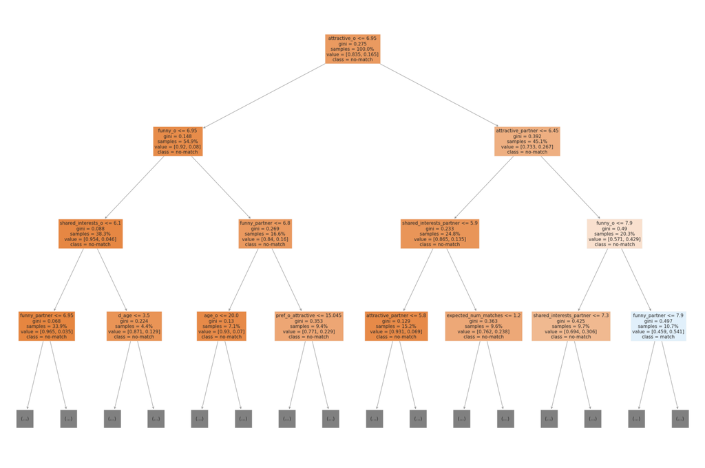

Después de aplicar el algoritmo de Random Forest, se obtuvo un ranking de atributos que indica que estos dos aspectos son los más relevantes para el modelo.

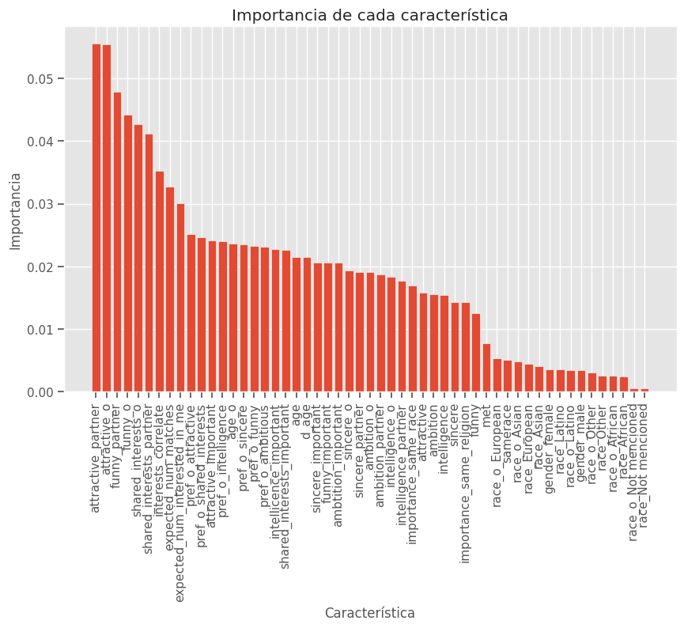

Se puede observar que los resultados son consistentes con los obtenidos en el árbol de decisión, ya que los atributos más importantes son los mismos. Esto refuerza la idea de que el atractivo físico y el sentido del humor son los factores más relevantes para generar un match.

## Resultados Pregunta 2

#### Grid Search:

Dada la metodología previamente expuesta se muestran los resultados para las distintas aplicaciones de grid search dados los clasificadores:

- Mejor combinación de parámetros para KNN:

  ```
          {'n_neighbors': 40, 'weights': 'distance'}
                 precision    recall  f1-score   support

          0        0.87      1.00      0.93       246
          1        1.00      0.33      0.50        54

   accuracy                            0.88       300
   macro avg       0.94      0.67      0.72       300
   weighted avg    0.90      0.88      0.85       300
  ```

- Mejor combinación de parámetros para Decision Tree

  ```
          {'max_depth': 2, 'min_samples_leaf': 1, 'min_samples_split': 2}
                 precision    recall  f1-score   support

          0      0.82      1.00      0.90       246
          1      0.00      0.00      0.00        54

   accuracy                          0.82       300
   macro avg     0.41      0.50      0.45       300
   weighted avg  0.67      0.82      0.74       300
  ```

#### Clasificadores:

En esta sección se presentan los resultados asociados a las métricas de los clasificadores:

- Clasificador Dummy:

  ```
   ----------------
                 precision    recall  f1-score   support

          0       0.52      0.52      0.52        54
          1       0.52      0.52      0.52        54

   accuracy                           0.52       108
   macro avg      0.52      0.52      0.52       108
   weighted avg   0.52      0.52      0.52       108

   ----------------
  ```

- Decision Tree:

  ```
   ----------------
                 precision    recall  f1-score   support

          0       0.76      0.51      0.61        57
          1       0.60      0.82      0.69        51

   accuracy                           0.66       108
   macro avg      0.68      0.67      0.65       108
   weighted avg   0.69      0.66      0.65       108

   ----------------
  ```

- Gaussian Naive Bayes:

  ```
   ----------------
                 precision    recall  f1-score   support

          0       0.65      0.73      0.69        49
          1       0.75      0.68      0.71        59

   accuracy                           0.70       108
   macro avg      0.70      0.71      0.70       108
   weighted avg   0.71      0.70      0.70       108

   ----------------
  ```

- KNN:

  ```
   ----------------
                 precision    recall  f1-score   support

          0       0.63      0.40      0.49        55
          1       0.55      0.75      0.63        53

   accuracy                           0.57       108
   macro avg      0.59      0.58      0.56       108
   weighted avg   0.59      0.57      0.56       108

   ----------------
  ```

- Support Vector Machines:

  ```
   ----------------
                 precision    recall  f1-score   support

          0       0.82      0.55      0.66        60
          1       0.60      0.85      0.71        48

   accuracy                           0.69       108
   macro avg      0.71      0.70      0.68       108
   weighted avg   0.73      0.69      0.68       108

   ----------------
  ```

Interpretación: Como se mencionó anteriormente, se entiende como mejor modelo el que, como primera instancia presenta mejores resultados en promedio para todas sus métricas, y al mismo tiempo el que posee una mayor precisión para detectar cuando una cita llega a hacer match, es decir, cuando precisión de 1 es más alto. Es por esto que para esta serie de modelos generados, se decide que Gauss Naive Bayes es el clasificador que funciona de una mejor manera para los datos del proyecto.

## Resultados Pregunta 3: Clustering

Después de aplicar el preprocesamiento descrito en la metodología y conservar únicamente los datos asociados a los participantes (sin incluir sus interacciones), se obtuvo un total de 530 puntos de datos.

A continuación, se presentan los resultados obtenidos a través del PCA para 2 y 3 componentes:

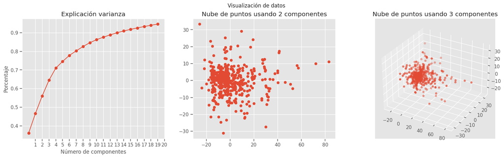

El análisis mediante PCA nos ha permitido reducir la dimensionalidad de los datos y visualizar la distribución de los puntos en un espacio de menor dimensión, lo que facilita la identificación de patrones o agrupaciones significativas.

#### Estimacion de numero de clusters:

Para estimar el número de clusters, como se mencionó en la metodología, se aplicarán los modelos de K-means y DBSCAN. Utilizaremos el método del codo para K-means y el método de la rodilla para DBSCAN (permitiendo que el algoritmo estime los clusters para el valor de eps proporcionado).

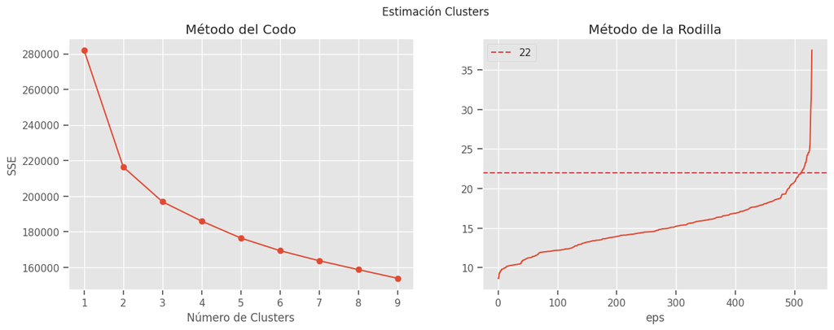

Se puede observar claramente que se sugieren 2 clusters naturales para el método K-means.

En cuanto al método DBSCAN, se estima que un valor óptimo de eps estaría en el rango de 21 a 23.

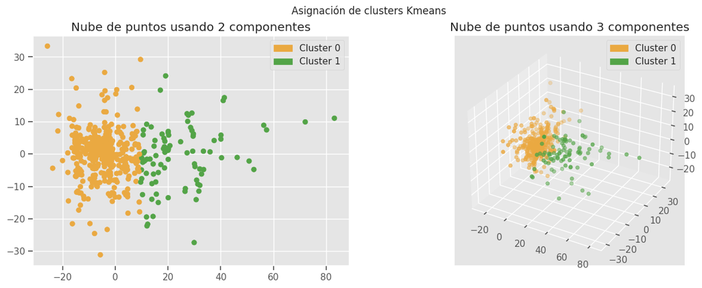

##### DBSCAN:

Para el valor óptimo de eps obtenido en DBSCAN, se observa que el algoritmo clasifica prácticamente todos los puntos como pertenecientes a un solo cluster, excepto por algunos outliers que son considerados como puntos separados. Es importante destacar que este resultado va en contra de las expectativas y no refleja la estructura esperada en los datos.

A pesar de esta discrepancia, por motivos de completitud y para tener en cuenta todas las opciones posibles, se considerará DBSCAN en las siguientes etapas del análisis.

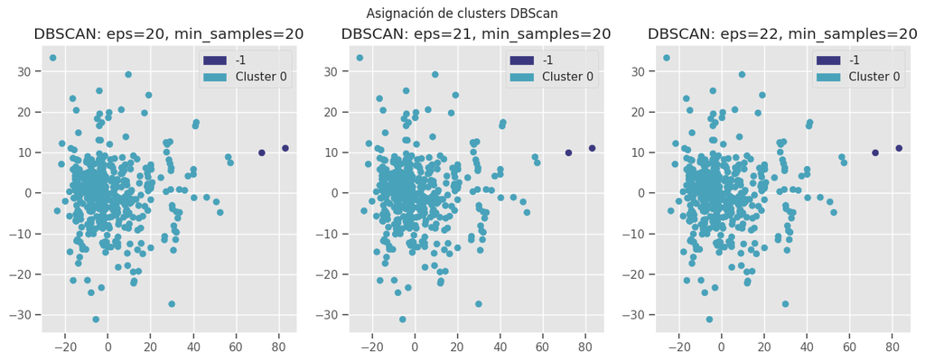

#### Validación:

Se procede a realizar la validación de los resultados obtenidos mediante el algoritmo K-means, utilizando dos técnicas importantes: la matriz de similitud y el coeficiente de Silhouette.

##### Matriz de similitud:

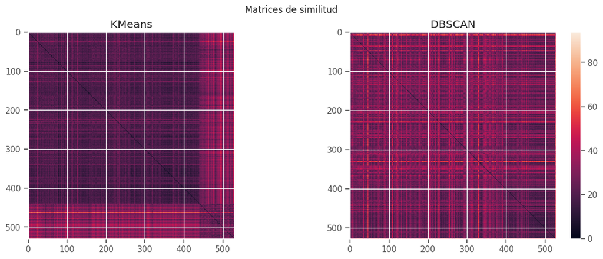

#### Coeficiente de Silhouette:

- K-Means: 0.3283410205657227
- DBScan: 0.6211661058921732

Para K-means, se puede observar una clusterización moderada con un coeficiente positivo pero no cercano a 1. En el caso de DBSCAN, se clasificaron todos los puntos en un mismo cluster, lo que resultó en un coeficiente de Silhouette más elevado y que representa una distancia media de todos los puntos.

Interpretación de clusters:

Dado los resultados poco satisfactorios de DBSCAN, nos enfocamos en interpretar los clusters generados por K-means. Para ello, agrupamos los datos según sus clusters y realizamos un análisis de sus estadísticas descriptivas. Esta evaluación abarca las categorías de Percepción propia, Preferencias, Calificaciones Obtenidas y Variables Categóricas. Entre todos los resultados obtenidos, se destacaron aquellos que mostraron una mayor diferencia entre los clusters, lo que sugiere que estos atributos tienen un impacto significativo en la formación de los grupos y en la probabilidad de hacer match entre los participantes.

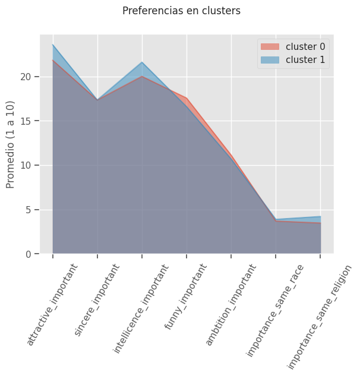

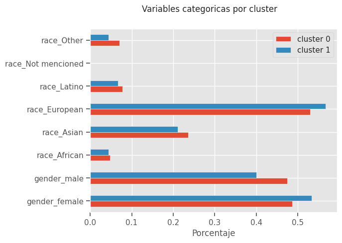

A pesar de que los clusters pueden tener características similares, podemos afirmar que el cluster 1 está compuesto principalmente por mujeres que tienden a otorgarle más importancia al atractivo e inteligencia. En contraste, el cluster 0 tiene una distribución más equitativa entre hombres y mujeres, y no presenta picos significativos de diferencias en las preferencias.

#### Matches por cluster:

Para investigar si estos clusters presentan distinciones en cuanto a las probabilidades de hacer match, se calcularon los porcentajes de decisiones positivas y matches dentro de cada cluster. Los resultados obtenidos son los siguientes:

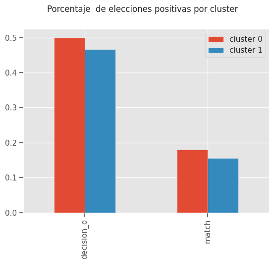

## Conclusiones derivadas de los resultados obtenidos y planificación futura:

### Experimento 1 Importancia de atributos : (¿Qué atributos son los más importantes a la hora de hacer un match?):

Es fundamental tener en cuenta que el árbol de decisión es un modelo y el Random Forest consiste en modelos "greedy", lo que implica que en cada iteración se dividen las variables en el hiperespacio utilizando aquellas que generan una mayor ganancia de información. Siguiendo esta lógica, se puede observar que los atributos relacionados con el atractivo físico y el sentido del humor son los que logran la mejor separación del espacio (como se puede apreciar en los nodos principales del árbol de decisión y en la feature importance del Random Forest). Los resultados obtenidos con el Random Forest son coherentes con los del árbol de decisión en este sentido.

En respuesta a la pregunta, podemos afirmar que los parámetros "attractive_partner" y "attractive_o" son los más influyentes a la hora de hacer match, seguidos por "funny_partner" y "funny_o". A partir de ahí, el resto de atributos no son significativamente más relevantes en la clasificación de las citas.

### Experimento 2 Clasificación: (¿Se puede predecir un match en base a las características de los participantes?):

Es importante destacar que, desde el principio, se esperaba que las 8000 filas se redujeran al menos a la mitad, es decir, a 4000 filas, por lo que el paso de este número a 1000 no representa una disminución significativa en términos de datos fiables y representativos del dataset.

En conclusión, basándonos en los resultados analizados, podemos afirmar con un 75% de precisión que si tenemos la información necesaria de dos personas, podemos predecir si terminarán haciendo match en una cita al ingresarlos en el modelo clasificador correspondiente.

### Experimento 3 Clustering:(¿Existen estereotipos reconocibles?¿Hay un estereotipo que es más propenso a hacer match ?)

Para K-means, se identificaron únicamente 2 clusters, mientras que DBscan no pudo separar clusters para su eps óptimo (ver visualización de clusters mediante PCA). La validación de los clusters de K-means indica una agrupación moderada, reflejada por un coeficiente de Silhouette no tan alto (0.3). La matriz de similitud muestra un cluster denso y otro más disperso.

Los resultados del clustering no cumplen completamente con las expectativas, ya que no se logró identificar una gran cantidad de "estereotipos" en las citas. Sin embargo, la caracterización de cada cluster encontrado permite señalar algunas diferencias entre ellos (ver observaciones de caracterización). En cuanto a si un estereotipo es propenso a hacer match, se puede afirmar que existen diferencias consistentes entre los dos clusters encontrados (en cuanto a decisiones y matches), pero estas diferencias no son tan significativas entre sí.

### Conclusiones finales y Planificación futura:

Las conclusiones que podemos extraer de los datos del proyecto están limitadas por la cantidad de estos. Nuestro dataset posee alrededor de ~8000 filas, y al ser procesadas, pueden reducirse considerablemente. Debido a esto, es importante mencionar que las conclusiones extraídas en este proyecto están sesgadas hacia este grupo particular de datos y no necesariamente representan una realidad generalizable. Además, la falta de datos claros puede conducir a patrones aleatorizados o poco definidos. Para mejorar el proyecto, sería recomendable buscar nuevas fuentes de datos que se puedan agregar para obtener patrones más claros y robustos.

En cuanto a la clasificación, en una planificación futura, sería ideal encontrar un punto de equilibrio entre la cantidad de filas que se pierden y la completitud de la data. Es decir, permitir que algunas filas con ciertos atributos vacíos se incluyan en el modelo de entrenamiento sin perder una buena representación del dataset. De esta manera, el modelo de clasificación será capaz de reflejar de manera más precisa la información contenida en los datos y, al recibir una consulta, podrá clasificar los datos con parámetros de mayor calidad y coherencia con la realidad simulada por los datos.

Finalmente, es recomendable orientar el análisis exploratorio de datos en función del objetivo final del proyecto para obtener indicadores relevantes sobre si se puede lograr el éxito deseado. Por ejemplo, si el objetivo es predecir matches, es recomendable explorar si existen ciertos factores o correlaciones que sugieran la probabilidad de un match. En este caso, el EDA realizado estuvo enfocado en responder preguntas generales y no se alineó directamente con los objetivos finales del proyecto.

Los algoritmos de machine learning pueden aplicarse a cualquier conjunto de datos, siempre y cuando estos tengan patrones internos (como se puede observar en los diferentes resultados obtenidos en el clustering). Sin embargo, es fundamental comprender lo que se está haciendo y validar los resultados de alguna manera para asegurar la robustez de los análisis y conclusiones.

## Anexo:

- Codigo completo: https://colab.research.google.com/drive/14FzcwQTW2XPdq-yqN0ZQW-0TNFEjUDqj#scrollTo=mbwTnF5YMi4C

## Fuentes y material de apoyo:

### Contribución exacta de cada integrante:

- Sebastián Brzovic: Presentación del video y clasificación.
- Patricio Yañez: Parcial análisis exploratorio, presentación del video, trabajo a futuro
- Tomás Alvarado: Avance en el experimento de clasificación, preparación del informe.
- José Tomás Aguilera: Refactorización metodología de clasificación según feedback
- Lukas Vasquez Verdejo: Clustering (implementación ,resultados ,conclusiones, refactorización metodología de clasificación según feedback, conclusiones finales)